# Homework 2

YUANJIAN ZHOU

Jan 24,2020

# 1 Part 1. Review Questions

## 1.

- $Pr(X<0.1)$ and $Pr(Y<0.1)$

$$Pr(X<0.1) = \frac{X-a}{b-a}=\frac{0.1-0}{1-0}=0.1\\
Pr(Y<0.1) = Pr(Y=0) = 0.5$$

- $E(X)$,$Var(X)$,$E(Y)$ and $Var(Y)$

$$E(X) = \frac{a+b}{2} = \frac{1}{2}\\
Var(X) = \frac{(b-a)^{2}}{12}=\frac{1}{12}\\
E(Y) = p = 0.5\\
Var(Y) = p*(1-p) = 0.25$$

- $E(0.3X+0.7Y)$ and $E(0.5X+0.5Y)$

$$E(0.3X+0.7Y) = 0.3E(X)+0.7E(Y) = 0.3*0.5+0.7*0.5=0.5\\
E(0.5X+0.5Y) = 0.5E(X)+0.5E(Y) = 0.5*0.5+0.5*0.5=0.5$$

- For any $\alpha \in [0;1]$, $E(\alpha X + (1-\alpha)Y)$
  $$\begin{align*}
  E(\alpha X+(1-\alpha) Y) &= \alpha E(X)+(1-\alpha)E(Y)\\
  &= \alpha *0.5+ (1- \alpha)*0.5=0.5\\
  \end{align*}$$
- Due to independence, COV(X,Y) = 0 and $E(\alpha X+(1-\alpha) Y) = 0.5$

$$\begin{align*}
VAR(\alpha X+(1-\alpha)Y) &= \alpha^2 VAR(X) + (1-\alpha)^2VAR(Y)=\frac{1}{12}\alpha^2 + (1-a)^2*\frac{1}{4}\\
\frac{dVAR}{d\alpha} &= \frac{1}{6}\alpha + \frac{1}{2}\alpha - \frac{1}{2}\\
\alpha &= \frac{3}{4}
\end{align*}$$

- So, I wil choose $\alpha$ = 0.75, because thus the variance will be the smaller.

## 2

- $Pr(X<-1.96)$

```r
sprintf("Pr(X < -1.96) = %#.3f", pnorm(-1.96, 0, 1))
```

```
## [1] "Pr(X < -1.96) = 0.025"
```

- $Pr(X>1.64)$

```r
sprintf("Pr(X > 1.64) = %#.3f", 1 - pnorm(1.64, 0, 1))
```

```
## [1] "Pr(X > 1.64) = 0.051"
```

- $Pr(-0.5<X<0.5)$

```r
sprintf("Pr(-0.5 < X < 0.5) = %#.3f", pnorm(0.5, 0, 1) - pnorm(-0.5, 0, 1))
```

```
## [1] "Pr(-0.5 < X < 0.5) = 0.383"
```

- $q_{0.01},q_{0.99}$

```r
sprintf("%s quantile is %#.3f", percent(0.01),qnorm(0.01,0,1))
```

```
## [1] "1% quantile is -2.326"
```

```r
sprintf("%s quantile is %#.3f", percent(0.99),qnorm(0.99,0,1))
```

```
## [1] "99% quantile is 2.326"
```

- $q_{0.05},q_{0.95}$

```r
sprintf("%s quantile is %#.3f", percent(0.05),qnorm(0.05,0,1))
```

```
## [1] "5% quantile is -1.645"
```

```r
sprintf("%s quantile is %#.3f", percent(0.95),qnorm(0.95,0,1))
```

```
## [1] "95% quantile is 1.645"
```

## 3

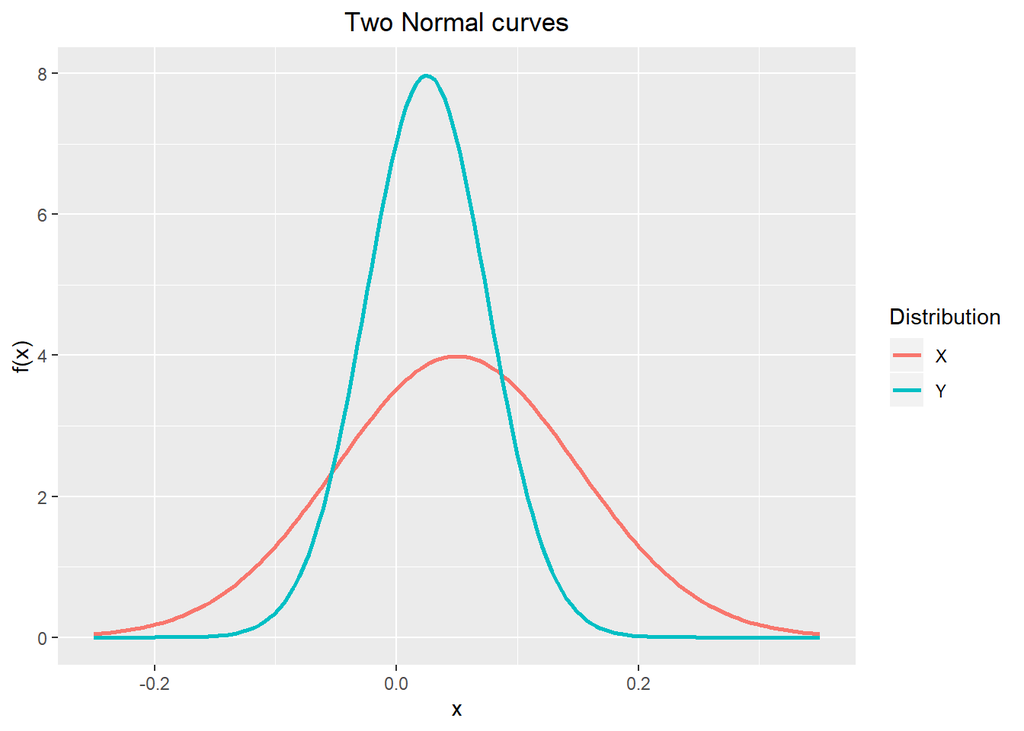

```r
# preparation
mu.x = 0.05
sigma.x = 0.1

mu.y = 0.025
sigma.y = 0.05

vals = seq(-0.25, 0.35, length=150)
df <- data.frame(vals, "X" = dnorm(vals, mu.x, sigma.x), "Y" = dnorm(vals, mu.y, sigma.y))

# plot
g <-  ggplot(data=df) +
  geom_line(aes(y = X, x = vals, color = "X"), size=1) +
  geom_line(aes(y = Y, x = vals, color = "Y"), size=1) +
  labs(colour = 'Distribution') +
  ylab("f(x)") +
  xlab("x") +
  ggtitle("Two Normal curves") +
  theme(plot.title = element_text(hjust = 0.5))
print(g)
```

- From the graph we can see that X has a higher mean and Y has a lower variance. That means that X has a higher return with a higher variance and Y has a lower return with a lower variance. So there exists a risk-return trade-off between the 2 stocks.
- Investment depends on the attitude towards risk, I am risk aversed, so I will invest in Y.

## 4

```r
risk = function(q, cc = F, ES_cal = F, mu_r = 0.05, sigma_r = 0.12){
    q_r = qnorm(q, mu_r, sigma_r)
    set.seed(46)
    r = rnorm(50000, mu_r, sigma_r)
    if (cc == F) {
      VaR = 100000 * q_r
      L1 = 100000 * r
    } else {
      VaR = 100000 * (exp(q_r) - 1)
      L1 = 100000 * (exp(r) - 1)
    }
      I = as.numeric(L1 <= VaR)
      ES = mean(L1 * I) / mean(I)
    if (!ES_cal){
      return(sprintf("The %s VaR is %#.3f", percent(q), VaR))
    } else{
      return(sprintf("The simulated %s ES is %#.3f", percent(q), ES))
    }
}
```

- $VaR_{0.01}$

```r
risk(0.01)
```

```
## [1] "The 1% VaR is -22916.174"
```

- $VaR_{0.05}$

```r
risk(0.05)
```

```
## [1] "The 5% VaR is -14738.244"
```

- $ES_{0.01}$

```r
risk(0.01, ES_cal = T)
```

```
## [1] "The simulated 1% ES is -27021.886"
```

- $ES_{0.05}$

```r
risk(0.05, ES_cal = T)
```

```
## [1] "The simulated 5% ES is -19863.853"
```

## 5

- $VaR_{0.01}$

```r
risk(0.01, cc = T)
```

```
## [1] "The 1% VaR is -20480.010"
```

- $VaR_{0.05}$

```r
risk(0.05, cc = T)
```

```
## [1] "The 5% VaR is -13703.611"
```

- $ES_{0.01}$

```r
risk(0.01, cc = T, ES_cal = T)
```

```
## [1] "The simulated 1% ES is -23632.017"
```

- $ES_{0.05}$

```r
risk(0.05, cc = T, ES_cal = T)
```

```
## [1] "The simulated 5% ES is -17933.028"
```

```r
risk(0.05, cc = T, mu_r = 0.6, sigma_r = 0.12 * sqrt(12))
```

```
## [1] "The 5% VaR is -8034.144"
```

- $VaR_{0.01}$ over the year

```r
risk(0.01, cc = T, mu_r = 0.6, sigma_r = 0.12 * sqrt(12))
```

```
## [1] "The 1% VaR is -30722.129"
```

- $ES_{0.05}$ over the year

```r
risk(0.05, cc = T, ES_cal = T, mu_r = 0.6, sigma_r = 0.12 * sqrt(12))
```

```
## [1] "The simulated 5% ES is -22105.708"
```

- $ES_{0.01}$ over the year

```r
risk(0.01, cc = T, ES_cal = T, mu_r = 0.6, sigma_r = 0.12 * sqrt(12))
```

```
## [1] "The simulated 1% ES is -39478.247"
```

## 6

- $\chi^2$

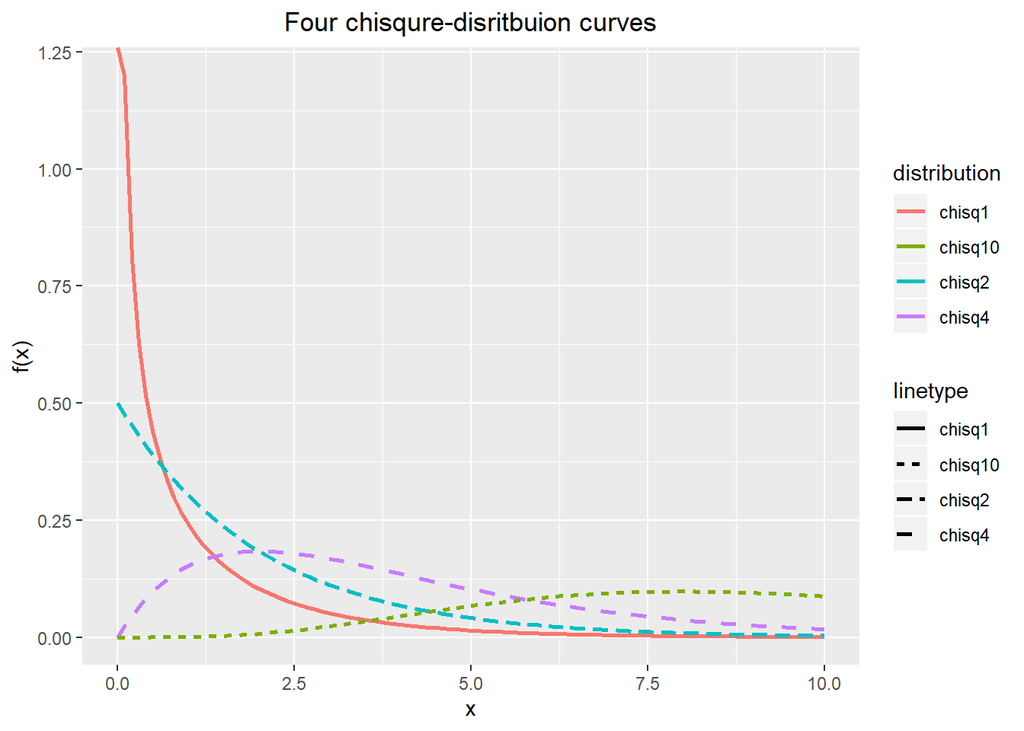

```r
vals = seq(0, 10, 0.1)
df2 = data.frame(vals, "chisq1" = dchisq(vals,1), "chisq2" = dchisq(vals,2), "chisq4" = dchisq(vals, 4), "chisq10" = dchisq(vals, 10))

g2 = ggplot(df2)+
  geom_line(aes(x = vals, y = chisq1,col = "chisq1",linetype = "chisq1"),size = 1)+
  geom_line(aes(x = vals, y = chisq2,col = "chisq2",linetype = "chisq2"),size = 1)+
  geom_line(aes(x = vals, y = chisq4,col = "chisq4",linetype = "chisq4"),size = 1)+
  geom_line(aes(x = vals, y = chisq10,col = "chisq10",linetype = "chisq10"),size = 1)+
  labs(col = "distribution")+
  xlab("x")+
  ylab("f(x)")+
  ggtitle("Four chisqure-disritbuion curves") +
  theme(plot.title = element_text(hjust = 0.5))

print(g2)
```

- $t$

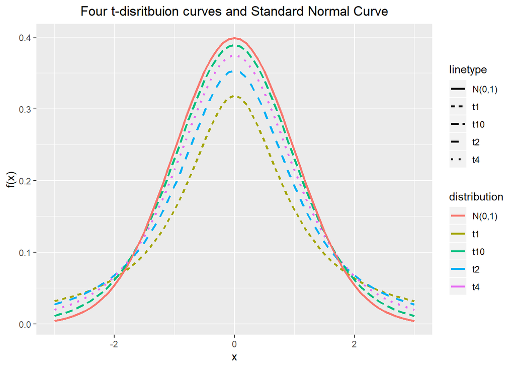

```r
vals = seq(-3, 3, 0.1)
df1 = data.frame(vals, "t1" = dt(vals,1), "t2" = dt(vals,2), "t4" = dt(vals, 4), "t10" = dt(vals, 10), "N" = dnorm(vals,0,1))

g1 = ggplot(df1)+
  geom_line(aes(x = vals, y = t1,col = "t1",linetype = "t1"),size = 1)+
  geom_line(aes(x = vals, y = t2,col = "t2",linetype = "t2"),size = 1)+
  geom_line(aes(x = vals, y = t4,col = "t4",linetype = "t4"),size = 1)+
  geom_line(aes(x = vals, y = t10,col = "t10",linetype = "t10"),size = 1)+
  geom_line(aes(x = vals, y = N, col = "N(0,1)",linetype = "N(0,1)"),size = 1)+
  labs(col = "distribution")+
  xlab("x")+
  ylab("f(x)")+
  ggtitle("Four t-disritbuion curves and Standard Normal Curve") +
  theme(plot.title = element_text(hjust = 0.5))

print(g1)
```

- I expect that 5% VaR of t distribution with d.f 2 is larger in absolute values.

## 7

- Marginal Distribution of X and Y, E[X], VAR(X), SD(X), E[Y], VAR(Y) and SD(Y)

$$f(X=x)= {\left\{\begin{matrix}
\frac{1}{8}&\ \ \ x=-1 \\
\frac{1}{4}&x=0 \\
\frac{1}{2}&x=1\\
\frac{1}{8}&x=2\\
\end{matrix}\right.}{}$$

$$f(Y=y)= {\left\{\begin{matrix}
\frac{3}{8}&\ \ \ y=-1 \\
\frac{5}{8}&y=1
\end{matrix}\right.}{}$$

$$\begin{align*}
E[X]&= \frac{1}{8} * (-1) + \frac{2}{8} * (0) +\frac{4}{8} * (1)+\frac{1}{8} * (2)=\frac{5}{8}\\
E[Y]&= \frac{3}{8} * (-1) + \frac{5}{8} * (1) = \frac{1}{4}\\
VAR(X) & = \frac{1}{8}(-1-\frac{5}{8})^2 + \frac{2}{8}(0-\frac{5}{8})^2 + \frac{4}{8}(1-\frac{5}{8})^2+\frac{1}{8}(2-\frac{5}{8})^2\\
&= \frac{47}{64}\\
SD(X) &= \frac{\sqrt{47}}{8}\\
VAR(Y) &= \frac{3}{8}(-1-\frac{1}{4})^2 + \frac{5}{8}(1-\frac{1}{4})^2\\
&=\frac{15}{16}\\
SD(Y) &= \frac{\sqrt{15}}{4}
\end{align*}$$

$$\begin{align*}
E[X|Y=1]&=\frac{1}{5} * (0) + \frac{3}{5} * (1) + \frac{1}{5} * (2)=1\\
E[Y|X=2]&= 1 * 1 = 1
\end{align*}$$

- VAR(X|Y=1), VAR(Y|X=2)
  $$\begin{align*}
  VAR(X|Y=1) &= \frac{1}{5}(0-1)^2 + \frac{3}{5}(1-1)^2 + \frac{1}{5}(2-1)^2 = \frac{2}{5}\\
  VAR(Y|X=2) &= 0
  \end{align*}$$

# 2 Part 2. R Exercises

## Problem 1

```r
set.seed(46)
X = rnorm(50000,0,1)
P = sum(X>=0.5)/length(X)
print(c("probability" = P))
```

```
## probability
##      0.3096
```

## Problem 2

```r
# Denote H = 1, T = 0
set.seed(46) # for reproductivity
guess = rbinom(50000,1,0.5) # my guess
friend = rbinom(50000,1,0.5) # friend's guess
wealth = rep(0,50000)
for (i in 1:50000){
  if (guess[i] == friend[i] & guess[i] == 1){
    wealth[i] = -3
  } else if (guess[i] == friend[i] & guess[i] == 0) {
      wealth[i] = -1
  } else {
    wealth[i] = 2
  }
}
expectation = mean(wealth)
expectation
```

```
## [1] -0.0099
```

## Problem 3

```r
set.seed(46) # for reproductivity
guess = rbinom(50000,1,0.36) # my guess
friend = rbinom(50000,1,0.5) # friend's guess
wealth = rep(0,50000)
for (i in 1:50000){
  if (guess[i] == friend[i] & guess[i] == 1){
    wealth[i] = -3
  } else if (guess[i] == friend[i] & guess[i] == 0) {
      wealth[i] = -1
  } else {
    wealth[i] = 2
  }
}
expectation = mean(wealth)
expectation
```

```
## [1] 0.13644
```

## Problem 4

```r
# we can write a function to get the expectation for different strategies of my friend.
ex = function(p){
  guess = rbinom(50000,1,0.36)
  friend = rbinom(50000,1,p)
  wealth = rep(0,50000)
  for (i in 1:50000){
    if (guess[i] == friend[i] & guess[i] == 1){
      wealth[i] = -3
    } else if (guess[i] == friend[i] & guess[i] == 0) {
      wealth[i] = -1
    } else {
    wealth[i] = 2
    }
  }
  expectation = mean(wealth)
  return(expectation)
}

# we will try different strategies of my friend:
p = seq(0,1,0.01)
expect = rep(0,length(p))
for (i in 1:length(p)) {
  expect[i] = ex(p[i])
}
sum(expect<=0) # show whether there is a negative or 0 expectation.
```

```
## [1] 0
```